# Practical Machine Learning Final Project

Jinwang Zou

March 30, 2018

## Project Description

Using devices such as *Jawbone Up*, *Nike FuelBand*, and *Fitbit* is now possible to collect a large amount of data about personal activity relatively inexpensively. One perspective of analyzing these data is evaluating how *much* activities they do, rather than *how well they do it*. This project aims to predict the manner in which people do the exercise. The training data used in this study are available here https://d396qusza40orc.cloudfront.net/predmachlearn/pml-training.csv and testing data here https://d396qusza40orc.cloudfront.net/predmachlearn/pml-testing.csv.

## Data

### Data loading

First, we will follow normal practice by splitting the data into 70/30 as training and testing data set. All strings like `NAs`, `#DIV/0!` and blank spaces are marked as missing data when reading in the data set.

```r
library(lattice)
library(ggplot2)
library(caret)
library(rpart)
library(rpart.plot)
library(RColorBrewer)
library(rattle)
library(randomForest)
library(knitr)
download.file("https://d396qusza40orc.cloudfront.net/predmachlearn/pml-training.csv",
              "weight-train.csv")
download.file("https://d396qusza40orc.cloudfront.net/predmachlearn/pml-testing.csv",
              "weight-test.csv")

training <- read.csv("weight-train.csv",na.strings=c("NA","#DIV/0!",""))
testing <- read.csv("weight-test.csv",na.strings=c("NA","#DIV/0!",""))

set.seed(12315)
inTrain <- createDataPartition(training$classe, p=0.7, list=FALSE)
mytraining <- training[inTrain, ]
mytesting <- training[-inTrain, ]
dim(mytraining);dim(mytesting)
```

```
## [1] 13737   160
```

```
## [1] 5885  160
```

To exclude missing data from final analysis, the following data cleaning steps are conducted: First, remove all Near Zero Variance variables as they do not have strong predictive power

```r
NZV <- nearZeroVar(mytraining)
mytraining <- mytraining[, -NZV]
mytesting  <- mytesting[, -NZV]
dim(mytraining);dim(mytesting)
```

```
## [1] 13737   132
```

```
## [1] 5885  132
```

Second, all columns with more than 90% `NAs` are excluded

```r
ANA <- sapply(mytraining,function(x) mean(is.na(x)))>0.90
mytraining <- mytraining[,ANA==FALSE]
mytesting <- mytesting[,ANA==FALSE]
dim(mytraining);dim(mytesting)
```

```
## [1] 13737    59
```

```
## [1] 5885   59
```

Third, the first five columns contain identification information so they are also excluded

```r
# Remove the following identification columns
mytraining <- mytraining[,-c(1:5)]
mytesting <- mytesting[,-c(1:5)]
dim(mytraining);dim(mytesting)
```

```
## [1] 13737    54
```

```
## [1] 5885   54
```

## Modeling

For modeling part, two algorithms are used. The first is decision tree and the second is random forest. After comparing the predictive power of the two algorithms, the one with higher predictive ability will be used to do the final prediction.

### Decision Tree

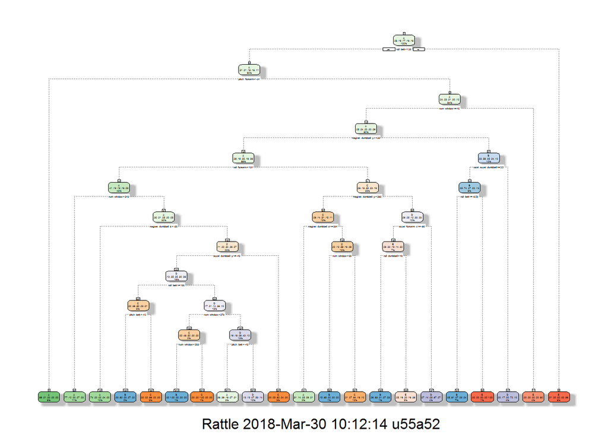

```r
set.seed(12345)
modFit1 <- rpart(classe ~ ., data=mytraining, method="class")
fancyRpartPlot(modFit1)
```

```r
prediction1 <- predict(modFit1,mytesting,type="class")
mytree <- confusionMatrix(prediction1,mytesting$classe)
mytree$overall
```

```
##       Accuracy          Kappa  AccuracyLower  AccuracyUpper   AccuracyNull
##   7.485132e-01   6.805521e-01   7.372218e-01   7.595577e-01   2.844520e-01
## AccuracyPValue  McnemarPValue
##   0.000000e+00   6.136835e-58
```

### Random Forest

```r
set.seed(12345)
modFit2 <- randomForest(classe ~., data=mytraining)
prediction2 <- predict(modFit2,mytesting,type="class")
rf <- confusionMatrix(prediction2,mytesting$classe)
rf$overall
```

```
##       Accuracy          Kappa  AccuracyLower  AccuracyUpper   AccuracyNull
##      0.9974511      0.9967758      0.9957995      0.9985727      0.2844520
## AccuracyPValue  McnemarPValue
##      0.0000000            NaN
```

## Final Predictions

```r
prediction <- predict(modFit2, testing, type = "class")
prediction
```

```
##  1  2  3  4  5  6  7  8  9 10 11 12 13 14 15 16 17 18 19 20
##  B  A  B  A  A  E  D  B  A  A  B  C  B  A  E  E  A  B  B  B
## Levels: A B C D E
```